# Capitulo_4_Uso_de_la_Regresion_Multiple

### 4.10.2 Transformación raíz cuadrada

```r
modelo_pol3_trans <- lm(sqrt(mpg) ~ vol + hp + I(hp^2), data = millaje)
summary(modelo_pol3_trans)
```

```
Call:
lm(formula = sqrt(mpg) ~ vol + hp + I(hp^2), data = millaje)

Residuals:
     Min       1Q   Median       3Q      Max
-0.70979 -0.22004 -0.05431  0.19640  0.95714

Coefficients:
              Estimate Std. Error t value Pr(>|t|)
(Intercept)  9.031e+00  2.232e-01  40.459  < 2e-16 ***
vol         -5.083e-03  2.024e-03  -2.512   0.0141 *
hp          -3.256e-02  3.453e-03  -9.429 1.59e-14 ***
I(hp^2)      6.117e-05  1.015e-05   6.027 5.21e-08 ***
---
Signif. codes:  0 '***' 0.001 '**' 0.01 '*' 0.05 '.' 0.1 ' ' 1

Residual standard error: 0.3448 on 78 degrees of freedom
Multiple R-squared:  0.8442,    Adjusted R-squared:  0.8383
F-statistic: 140.9 on 3 and 78 DF,  p-value: < 2.2e-16
```

```r
shapiro.test(modelo_pol3_trans$residuals)
```

```
    Shapiro-Wilk normality test

data:  modelo_pol3_trans$residuals
W = 0.97571, p-value = 0.1217
```

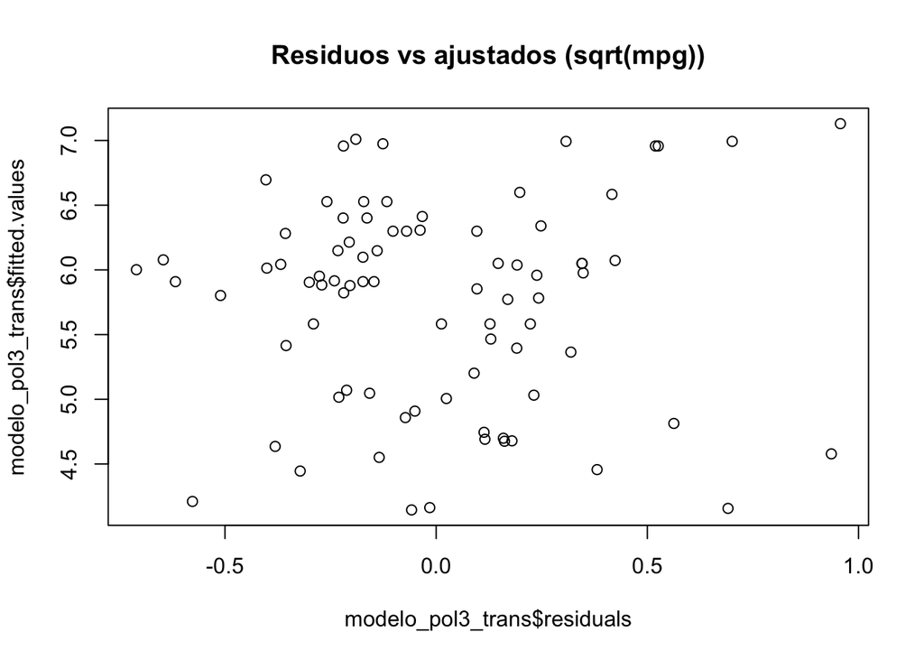

```r
plot(modelo_pol3_trans$residuals, modelo_pol3_trans$fitted.values,
     main = "Residuos vs ajustados (sqrt(mpg))")
```

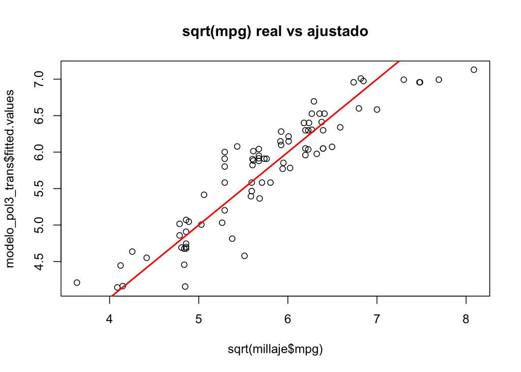

```r
plot(sqrt(millaje$mpg), modelo_pol3_trans$fitted.values,
     main = "sqrt(mpg) real vs ajustado")
lines(c(4, 8), c(4, 8), col = "red", lwd = 2)
```

### 4.10.3 Transformación 1/sqrt(mpg)

```r
modelo_pol4_trans <- lm(1/sqrt(mpg) ~ vol + hp + I(hp^2), data = millaje)
summary(modelo_pol4_trans)
```

```
Call:
lm(formula = 1/sqrt(mpg) ~ vol + hp + I(hp^2), data = millaje)

Residuals:
      Min        1Q    Median        3Q       Max
-0.032371 -0.007178  0.001601  0.005842  0.044607

Coefficients:
              Estimate Std. Error t value Pr(>|t|)
(Intercept)  8.354e-02  7.154e-03  11.677  < 2e-16 ***
vol          1.823e-04  6.486e-05   2.811 0.006249 **
hp           8.284e-04  1.107e-04   7.485 9.28e-11 ***
I(hp^2)     -1.219e-06  3.253e-07  -3.747 0.000341 ***
---
Signif. codes:  0 '***' 0.001 '**' 0.01 '*' 0.05 '.' 0.1 ' ' 1

Residual standard error: 0.01105 on 78 degrees of freedom
Multiple R-squared:  0.8501,    Adjusted R-squared:  0.8444
F-statistic: 147.5 on 3 and 78 DF,  p-value: < 2.2e-16
```

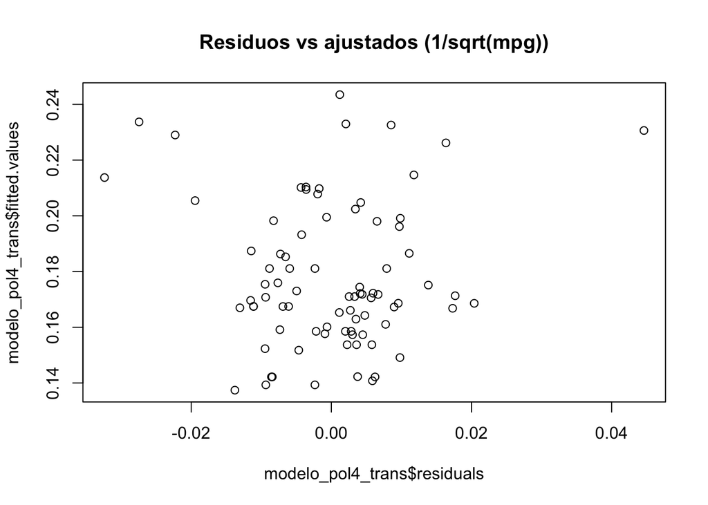

```r
plot(modelo_pol4_trans$residuals, modelo_pol4_trans$fitted.values,
     main = "Residuos vs ajustados (1/sqrt(mpg))")
```

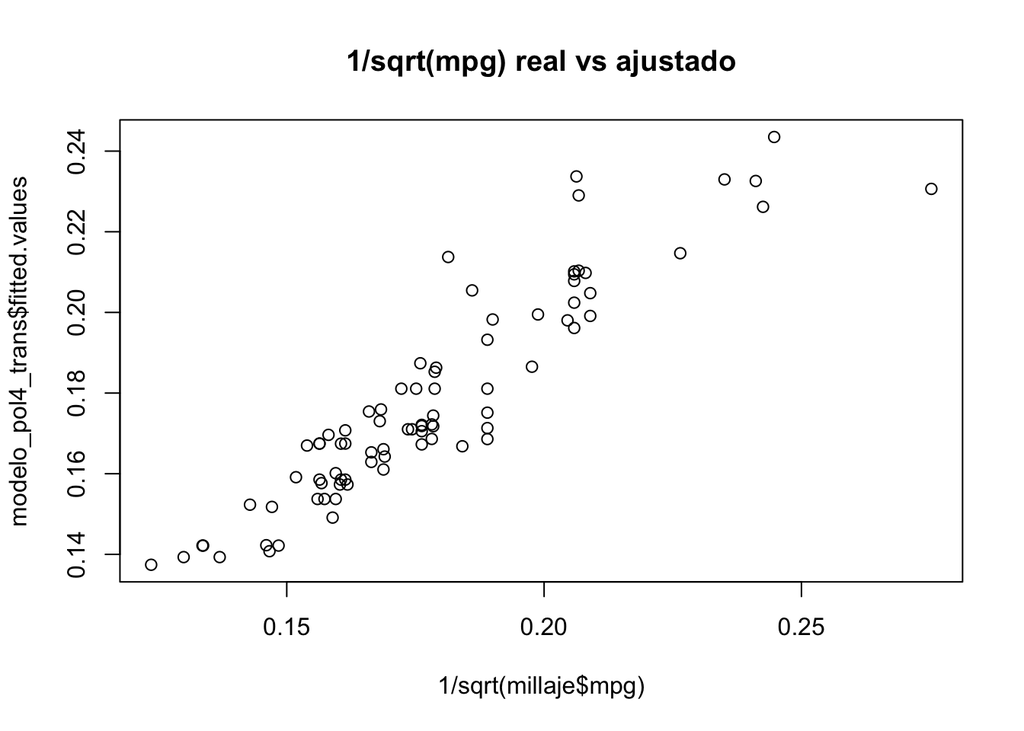

```r
plot(1/sqrt(millaje$mpg), modelo_pol4_trans$fitted.values,
     main = "1/sqrt(mpg) real vs ajustado")
```

```r
shapiro.test(modelo_pol4_trans$residuals)
```

```
    Shapiro-Wilk normality test

data:  modelo_pol4_trans$residuals
W = 0.94789, p-value = 0.002249
```

### 4.10.4 Transformaciones más complejas

```r
modelo_pol2_tran_2 <- lm(log(1 + mpg) ~ vol + hp + log(1 + hp) + I(hp^2),
                         data = millaje)
summary(modelo_pol2_tran_2)
```

```
Call:
lm(formula = log(1 + mpg) ~ vol + hp + log(1 + hp) + I(hp^2),
    data = millaje)

Residuals:
     Min       1Q   Median       3Q      Max
-0.35624 -0.06687 -0.00430  0.07828  0.29355

Coefficients:
              Estimate Std. Error t value Pr(>|t|)
(Intercept)  7.340e+00  1.236e+00   5.937 7.87e-08 ***
vol         -2.076e-03  6.602e-04  -3.144  0.00237 **
hp           2.231e-03  5.630e-03   0.396  0.69297
log(1 + hp) -8.215e-01  3.675e-01  -2.236  0.02827 *
I(hp^2)     -2.564e-06  9.486e-06  -0.270  0.78768
---
Signif. codes:  0 '***' 0.001 '**' 0.01 '*' 0.05 '.' 0.1 ' ' 1

Residual standard error: 0.1111 on 77 degrees of freedom
Multiple R-squared:  0.8645,    Adjusted R-squared:  0.8574
F-statistic: 122.8 on 4 and 77 DF,  p-value: < 2.2e-16
```

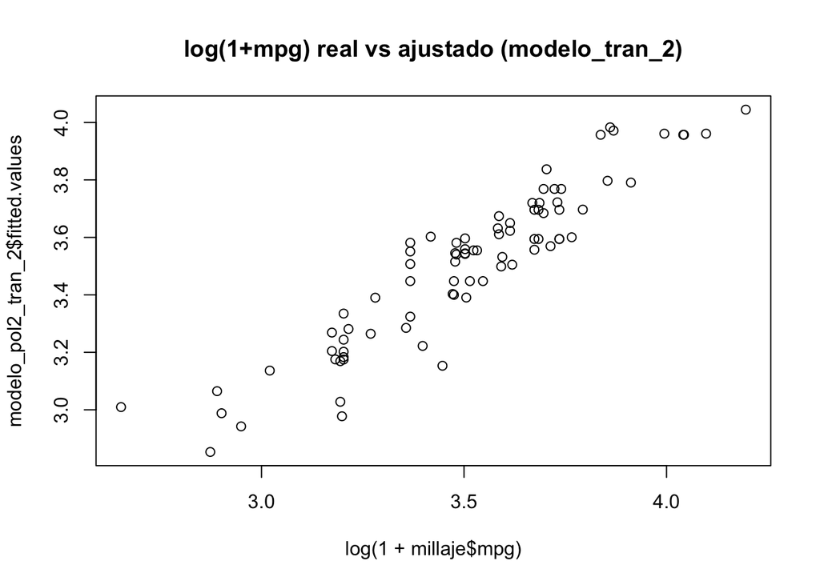

```r
plot(log(1 + millaje$mpg), modelo_pol2_tran_2$fitted.values,
     main = "log(1+mpg) real vs ajustado (modelo_tran_2)")
```

```r
shapiro.test(modelo_pol2_tran_2$residuals)
```

```
    Shapiro-Wilk normality test

data:  modelo_pol2_tran_2$residuals
W = 0.98972, p-value = 0.7645
```

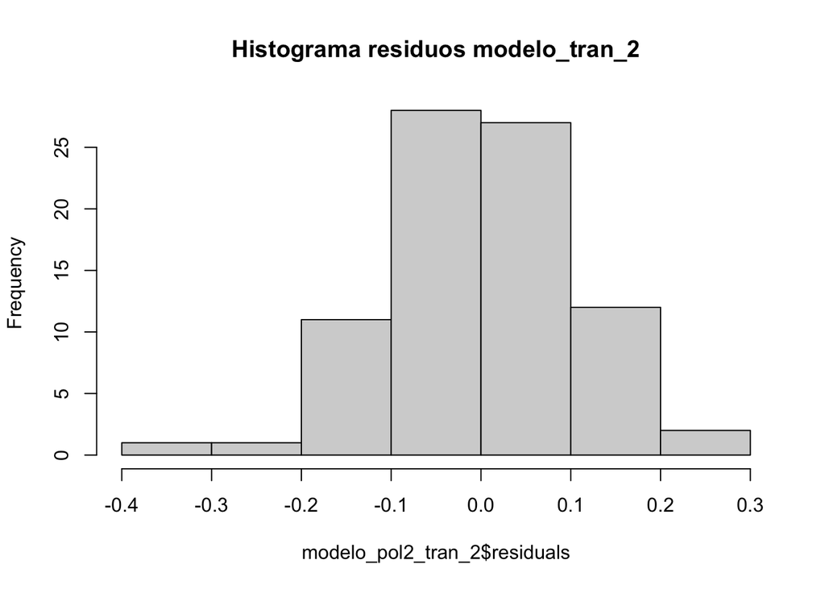

```r
hist(modelo_pol2_tran_2$residuals, main = "Histograma residuos modelo_tran_2")
```

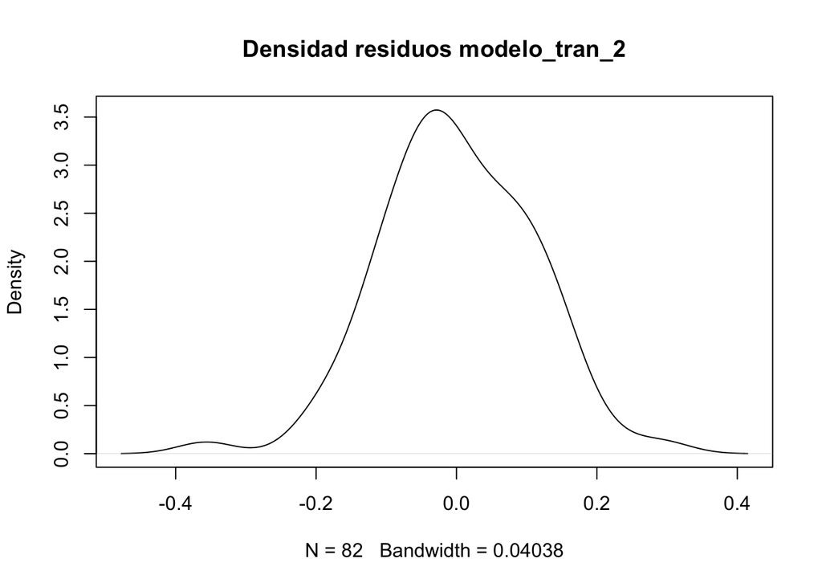

```r
plot(density(modelo_pol2_tran_2$residuals),
     main = "Densidad residuos modelo_tran_2")
```

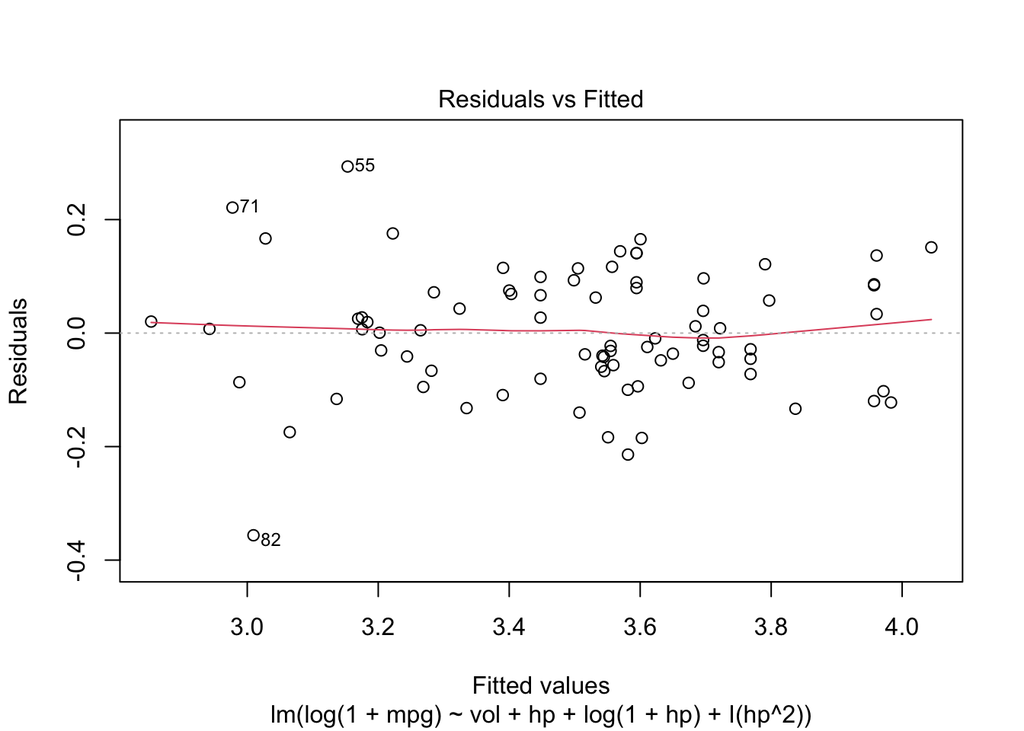

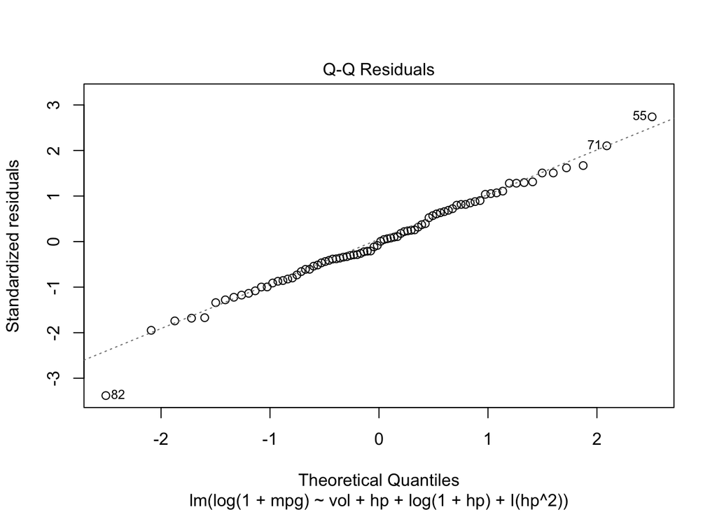

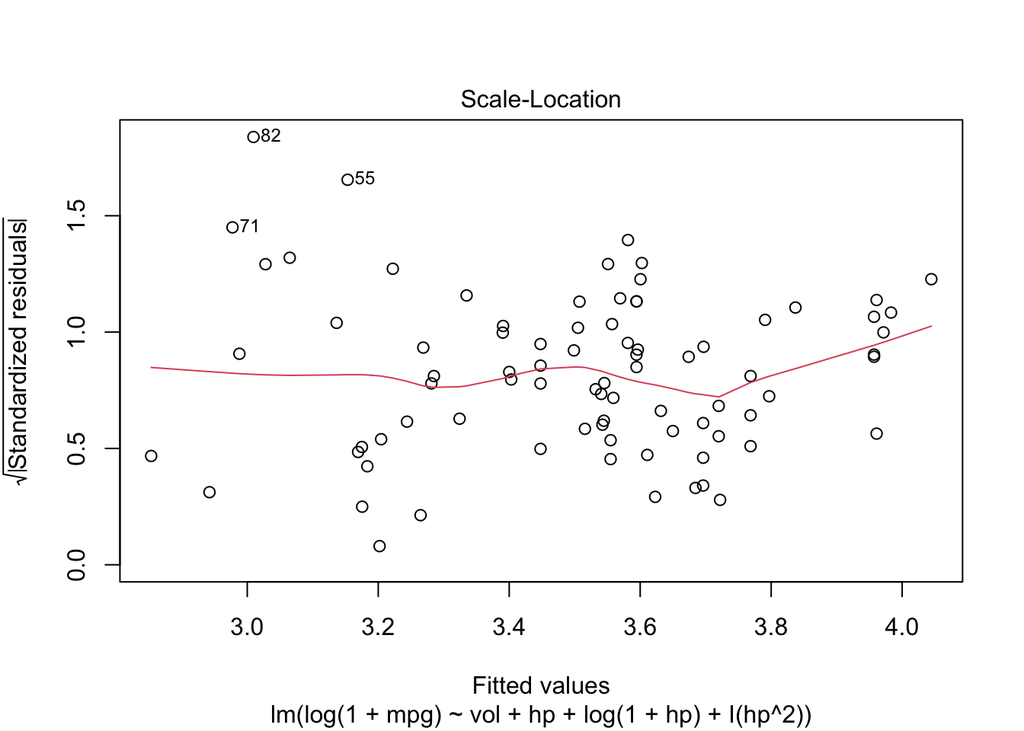

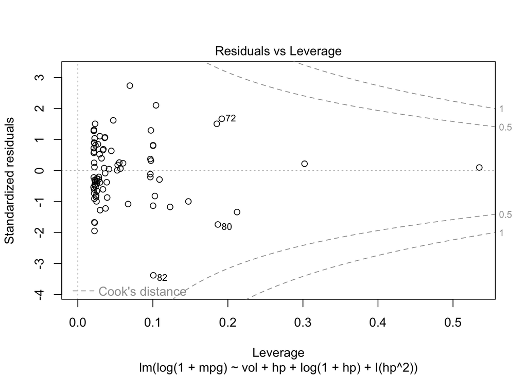

```r
plot(modelo_pol2_tran_2)
```

Otro modelo más flexible:

```r
modelo_pol2_tran_3 <- lm(log(1 + mpg) ~ hp + I(1/hp) + I(1/(hp^2)) +
                           log(1 + hp) + I(hp^2),
                         data = millaje)
summary(modelo_pol2_tran_3)
```

```
Call:
lm(formula = log(1 + mpg) ~ hp + I(1/hp) + I(1/(hp^2)) + log(1 +
    hp) + I(hp^2), data = millaje)

Residuals:
     Min       1Q   Median       3Q      Max
-0.33860 -0.07127 -0.01969  0.07723  0.30307

Coefficients:
              Estimate Std. Error t value Pr(>|t|)
(Intercept) -2.034e+01  7.517e+01  -0.271    0.787
hp          -3.355e-02  8.029e-02  -0.418    0.677
I(1/hp)      4.093e+02  1.224e+03   0.334    0.739
I(1/(hp^2)) -5.165e+03  1.705e+04  -0.303    0.763
log(1 + hp)  5.049e+00  1.558e+01   0.324    0.747
I(hp^2)      3.600e-05  7.142e-05   0.504    0.616

Residual standard error: 0.1187 on 76 degrees of freedom
Multiple R-squared:  0.8475,    Adjusted R-squared:  0.8374
F-statistic: 84.45 on 5 and 76 DF,  p-value: < 2.2e-16
```

```r
shapiro.test(modelo_pol2_tran_3$residuals)
```

```
    Shapiro-Wilk normality test

data:  modelo_pol2_tran_3$residuals
W = 0.98744, p-value = 0.6104
```

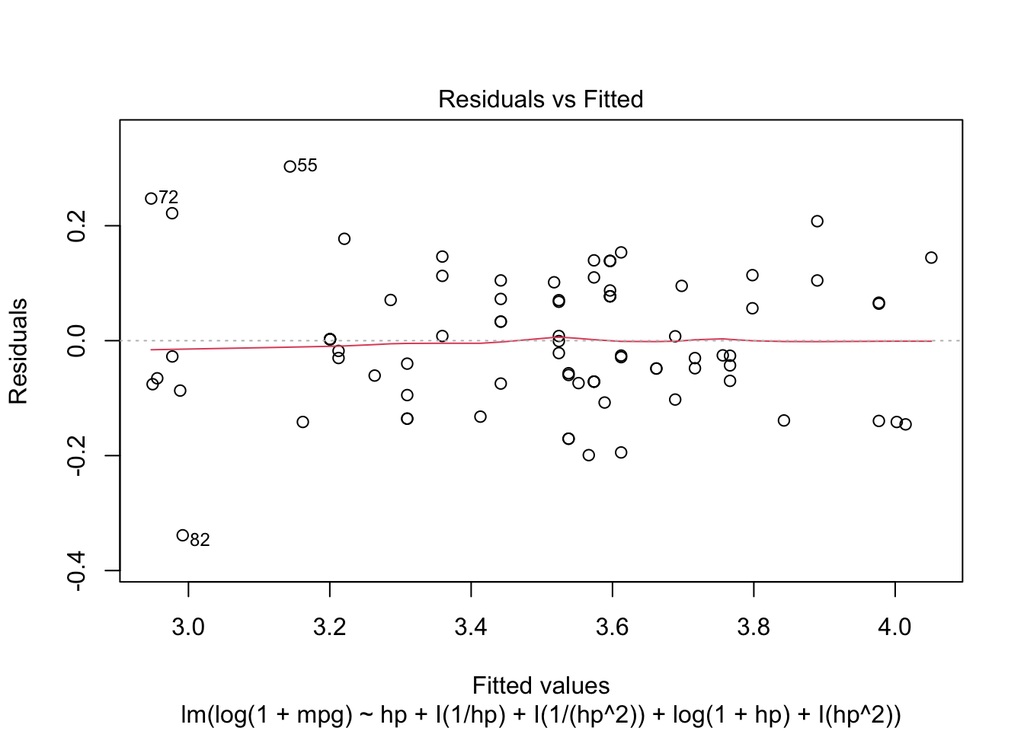

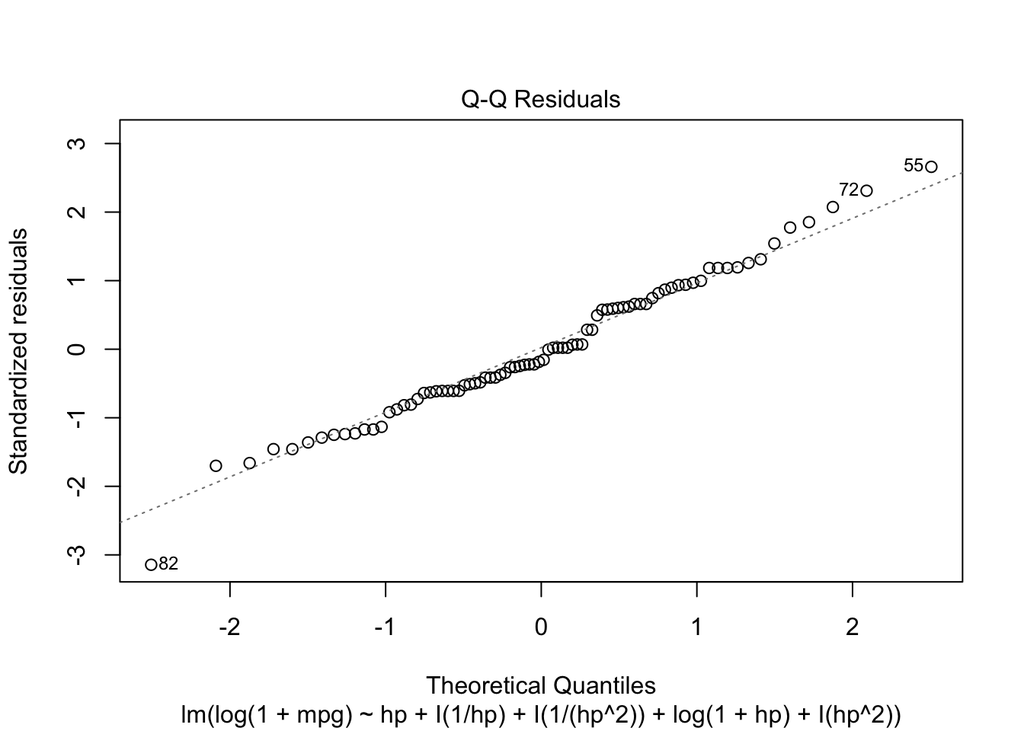

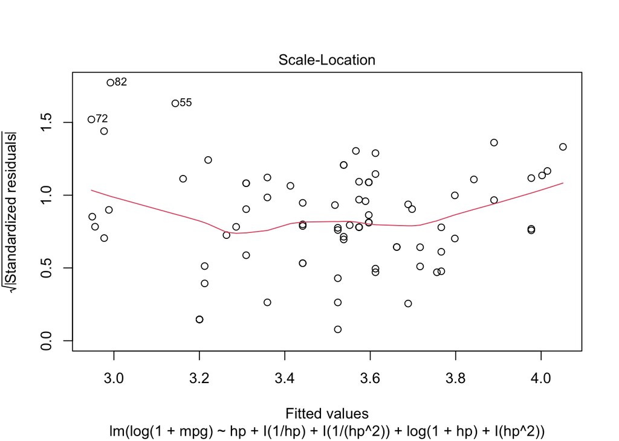

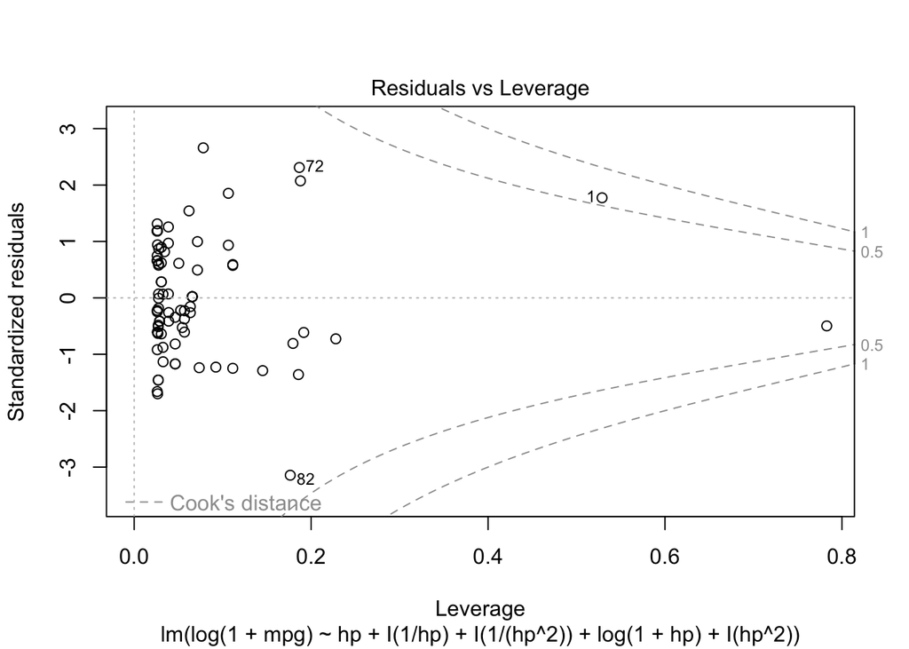

```r
plot(modelo_pol2_tran_3)
```

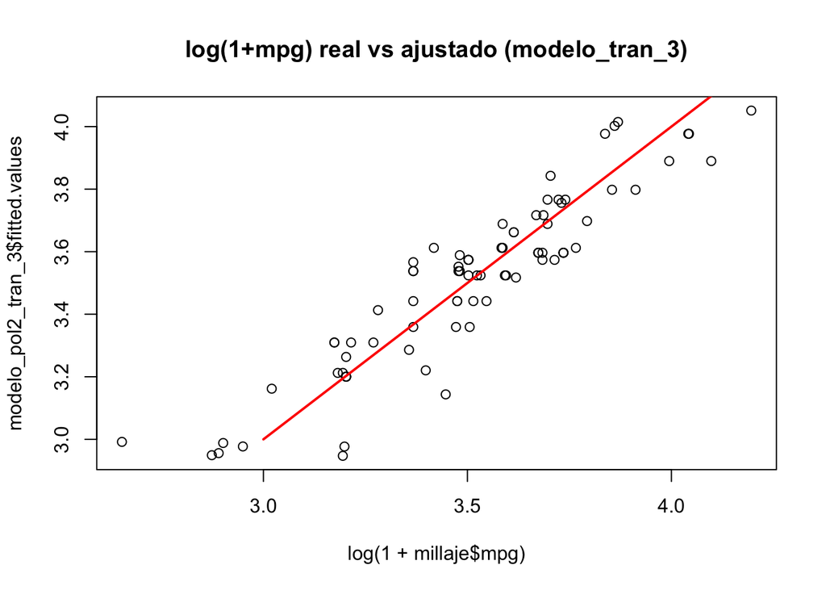

```r
plot(log(1 + millaje$mpg), modelo_pol2_tran_3$fitted.values,
     main = "log(1+mpg) real vs ajustado (modelo_tran_3)")
lines(c(3, 4.5), c(3, 4.5), col = "red", lwd = 2)
```

### 4.10.5 Modelos sin constante y selección

```r
modelo_pol2_tran_4 <- lm(log(1 + mpg) ~ hp + I(1/hp) + I(1/(hp^2)) +
                           log(1 + hp) + I(hp^2) - 1,
                         data = millaje)
summary(modelo_pol2_tran_4)
```

```
Call:
lm(formula = log(1 + mpg) ~ hp + I(1/hp) + I(1/(hp^2)) + log(1 +
    hp) + I(hp^2) - 1, data = millaje)

Residuals:
     Min       1Q   Median       3Q      Max
-0.34452 -0.07355 -0.01464  0.07509  0.30562

Coefficients:
              Estimate Std. Error t value Pr(>|t|)
hp          -1.202e-02  1.098e-02  -1.094   0.2772
I(1/hp)      7.934e+01  1.074e+02   0.738   0.4625
I(1/(hp^2)) -6.299e+02  3.147e+03  -0.200   0.8419
log(1 + hp)  8.319e-01  3.658e-01   2.274   0.0258 *
I(hp^2)      1.725e-05  1.732e-05   0.996   0.3223
---
Signif. codes:  0 '***' 0.001 '**' 0.01 '*' 0.05 '.' 0.1 ' ' 1

Residual standard error: 0.1179 on 77 degrees of freedom
Multiple R-squared:  0.9989,    Adjusted R-squared:  0.9989
F-statistic: 1.459e+04 on 5 and 77 DF,  p-value: < 2.2e-16
```

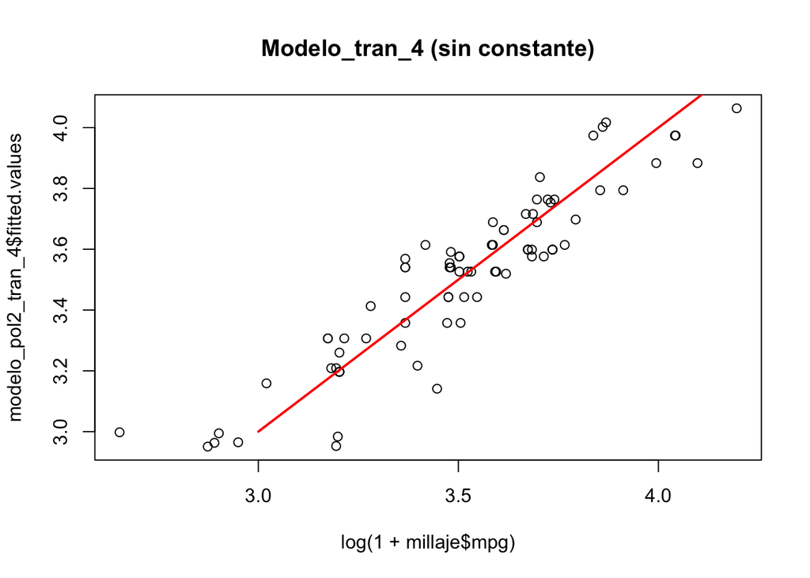

```r
plot(log(1 + millaje$mpg), modelo_pol2_tran_4$fitted.values,
     main = "Modelo_tran_4 (sin constante)")
lines(c(3, 4.5), c(3, 4.5), col = "red", lwd = 2)
```

```r
modelo_pol2_tran_5 <- lm(log(1 + mpg) ~ hp + I(1/hp) + log(1 + hp) + I(hp^2) - 1,
                         data = millaje)
summary(modelo_pol2_tran_5)
```

```
Call:
lm(formula = log(1 + mpg) ~ hp + I(1/hp) + log(1 + hp) + I(hp^2) -
    1, data = millaje)

Residuals:
     Min       1Q   Median       3Q      Max
-0.33926 -0.07379 -0.01700  0.07535  0.30724

Coefficients:
              Estimate Std. Error t value Pr(>|t|)
hp          -1.410e-02  3.554e-03  -3.967 0.000161 ***
I(1/hp)      5.795e+01  1.116e+01   5.194  1.6e-06 ***
log(1 + hp)  9.030e-01  8.687e-02  10.394  < 2e-16 ***
I(hp^2)      2.041e-05  7.119e-06   2.867 0.005328 **
---
Signif. codes:  0 '***' 0.001 '**' 0.01 '*' 0.05 '.' 0.1 ' ' 1

Residual standard error: 0.1172 on 78 degrees of freedom
Multiple R-squared:  0.9989,    Adjusted R-squared:  0.9989
F-statistic: 1.846e+04 on 4 and 78 DF,  p-value: < 2.2e-16
```

```r
shapiro.test(modelo_pol2_tran_5$residuals)
```

```
    Shapiro-Wilk normality test

data:  modelo_pol2_tran_5$residuals
W = 0.98884, p-value = 0.7058
```

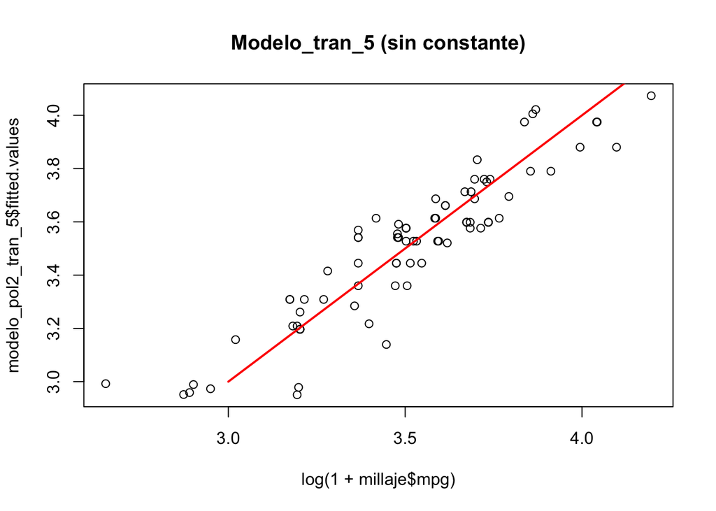

```r
plot(log(1 + millaje$mpg), modelo_pol2_tran_5$fitted.values,
     main = "Modelo_tran_5 (sin constante)")
lines(c(3, 4.5), c(3, 4.5), col = "red", lwd = 2)
```

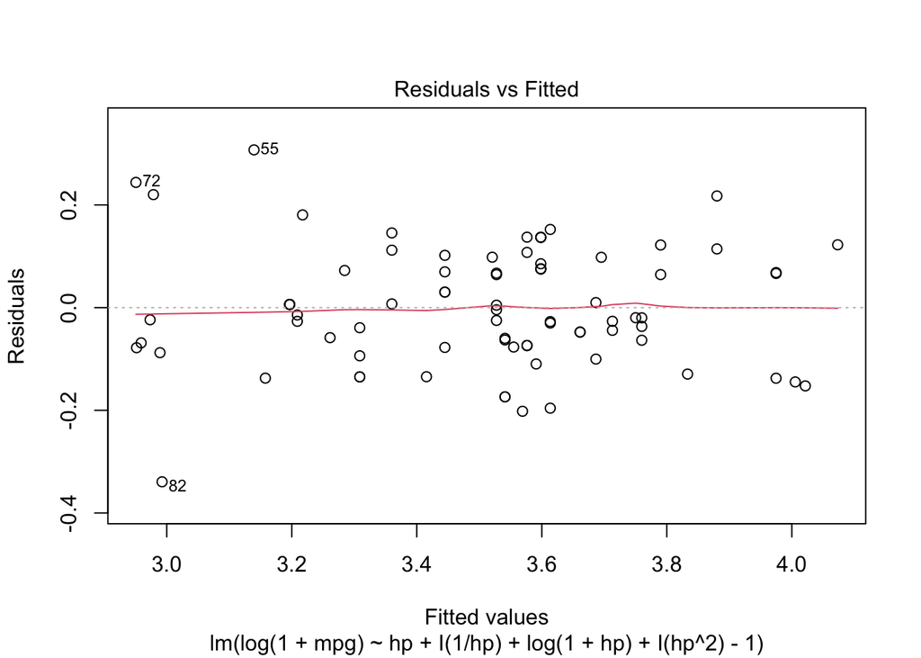

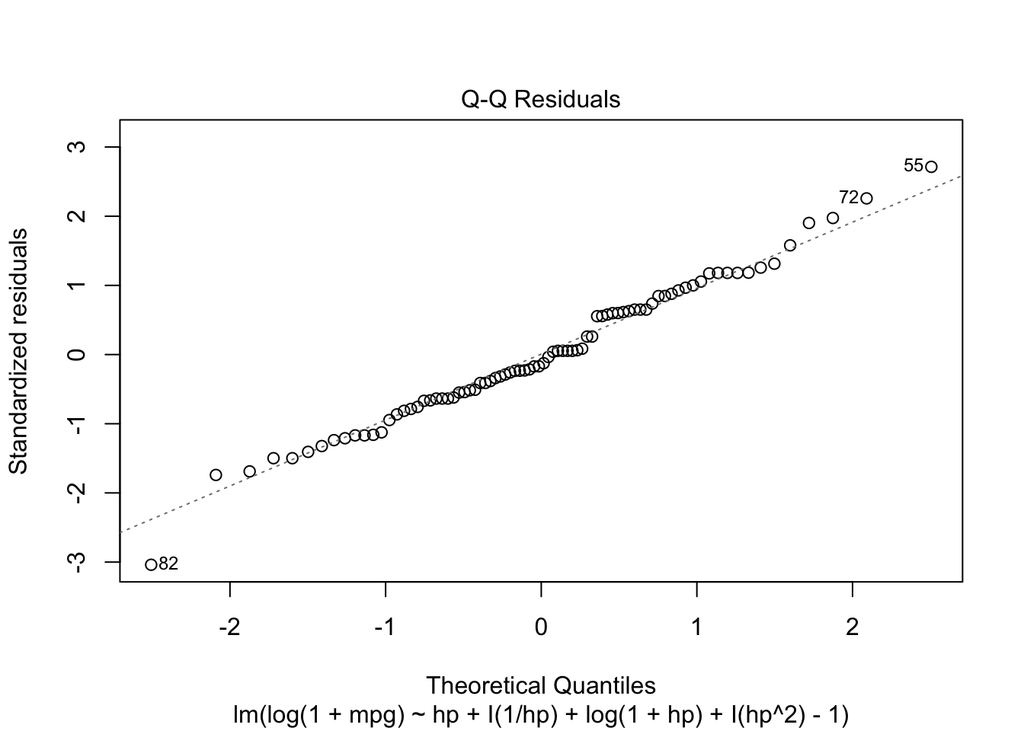

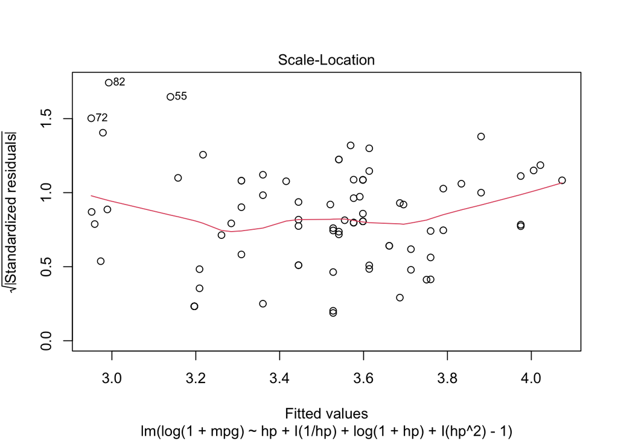

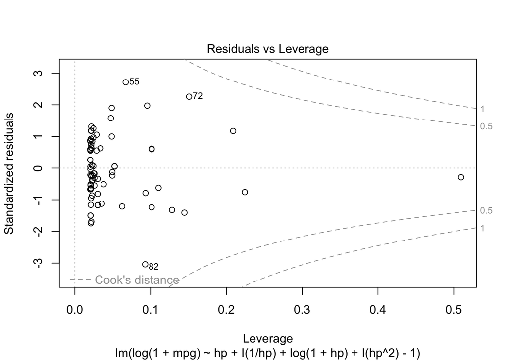

```r
plot(modelo_pol2_tran_5)
```

### 4.10.6 Un modelo candidato “bueno”

```r
modelo_pol2_tran_6 <- lm(log(1 + mpg) ~ log(1 + hp) - 1, data = millaje)
summary(modelo_pol2_tran_6)
```

```
Call:
lm(formula = log(1 + mpg) ~ log(1 + hp) - 1, data = millaje)

Residuals:
    Min      1Q  Median      3Q     Max
-1.3860 -0.3480  0.1168  0.3870  1.3059

Coefficients:
            Estimate Std. Error t value Pr(>|t|)
log(1 + hp)  0.73870    0.01383   53.42   <2e-16 ***
---
Signif. codes:  0 '***' 0.001 '**' 0.01 '*' 0.05 '.' 0.1 ' ' 1

Residual standard error: 0.5883 on 81 degrees of freedom
Multiple R-squared:  0.9724,    Adjusted R-squared:  0.9721
F-statistic:  2854 on 1 and 81 DF,  p-value: < 2.2e-16
```

```r
shapiro.test(modelo_pol2_tran_6$residuals)
```

```
    Shapiro-Wilk normality test

data:  modelo_pol2_tran_6$residuals
W = 0.97148, p-value = 0.06443
```

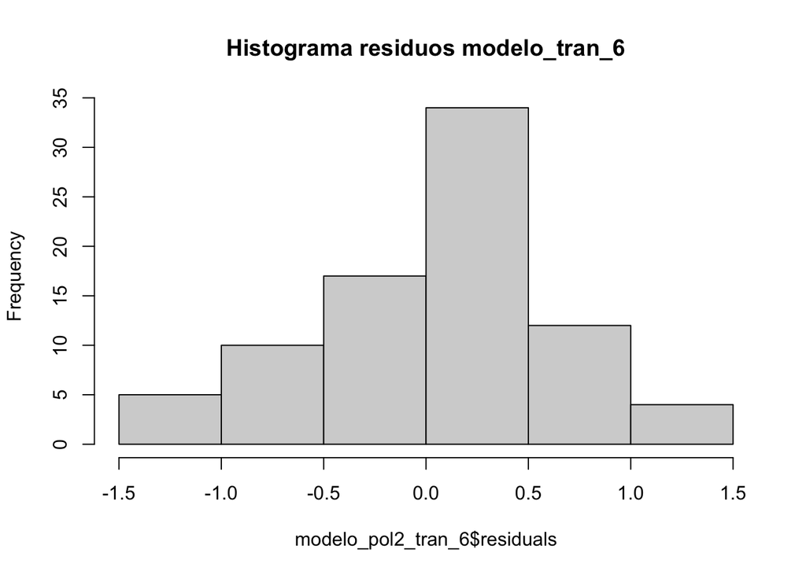

```r
hist(modelo_pol2_tran_6$residuals,
     main = "Histograma residuos modelo_tran_6")
```

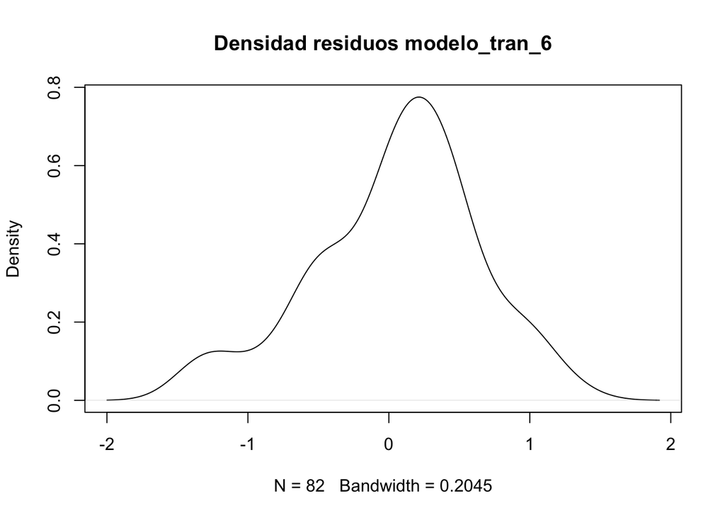

```r
plot(density(modelo_pol2_tran_6$residuals),
     main = "Densidad residuos modelo_tran_6")
```

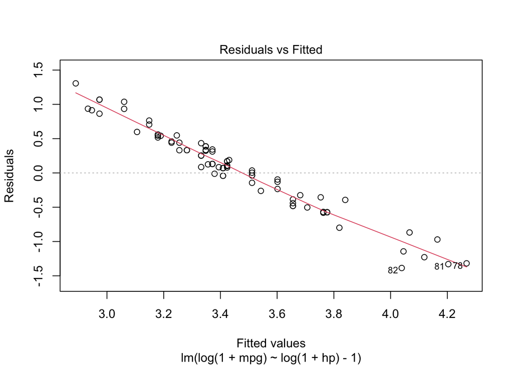

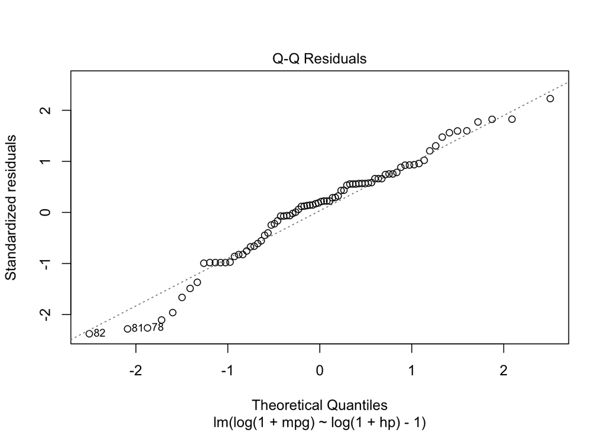

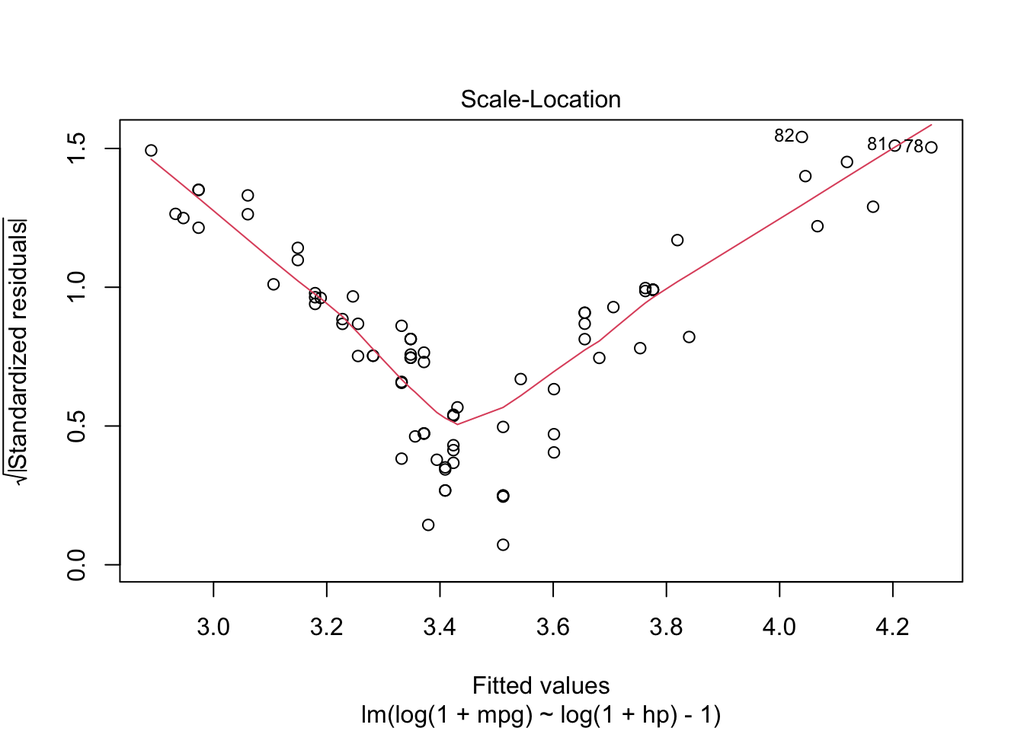

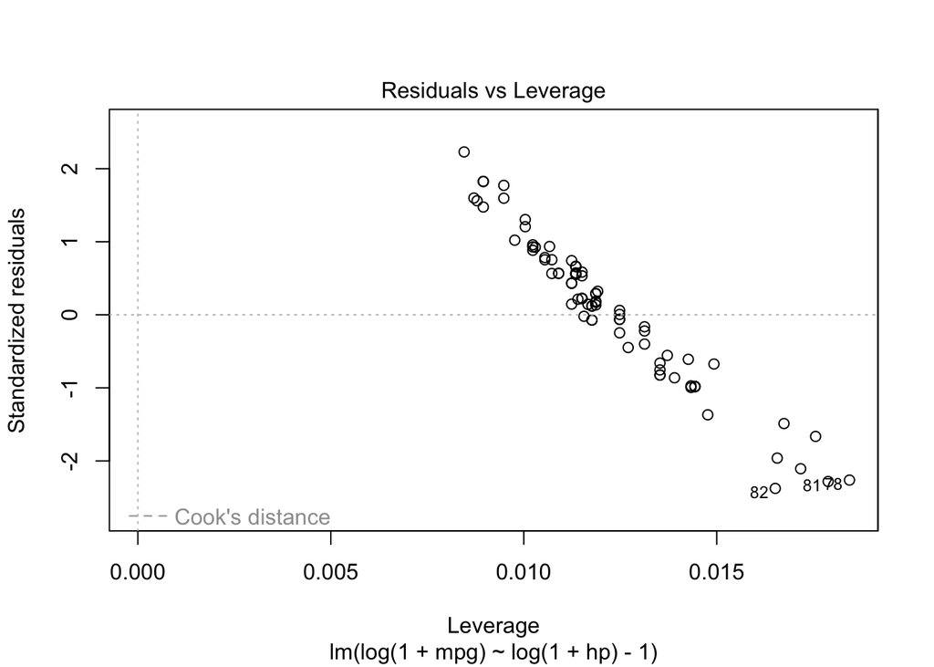

```r
plot(modelo_pol2_tran_6)
```

```r
modelo_pol2_tran_7 <- lm(log(1 + mpg) ~ vol + log(1 + hp) - 1, data = millaje)
summary(modelo_pol2_tran_7)
```

```
Call:
lm(formula = log(1 + mpg) ~ vol + log(1 + hp) - 1, data = millaje)

Residuals:
    Min      1Q  Median      3Q     Max
-1.3617 -0.3668  0.1028  0.4405  1.2853

Coefficients:
            Estimate Std. Error t value Pr(>|t|)
vol         0.003047   0.002943   1.035    0.304
log(1 + hp) 0.674633   0.063404  10.640   <2e-16 ***
---
Signif. codes:  0 '***' 0.001 '**' 0.01 '*' 0.05 '.' 0.1 ' ' 1

Residual standard error: 0.588 on 80 degrees of freedom
Multiple R-squared:  0.9728,    Adjusted R-squared:  0.9721
F-statistic:  1429 on 2 and 80 DF,  p-value: < 2.2e-16
```

**Nota**

En la práctica, al elegir entre varios modelos transformados, debes considerar:

- Supuestos sobre los **residuos** (normalidad, homocedasticidad).
- Interpretabilidad económica de los coeficientes.
- Capacidad predictiva (idealmente evaluada fuera de muestra).
- Parsimonia: preferir el modelo más simple que explique bien los datos.

# 5 Cierre del laboratorio

En este laboratorio trabajaste con:

- Regresión múltiple con **eliminación de variables irrelevantes**.
- Inclusión de **interacciones** y términos **cuadráticos**.
- Visualizaciones 3D de superficies de regresión.
- Modelos polinomiales de distintos grados.
- Comparación de modelos vía **ANOVA**.
- Uso de **transformaciones** (log, raíz, recíprocos) para mejorar los supuestos.

Todo esto forma parte del “arsenal” que usarás en cursos posteriores de econometría y en aplicaciones reales para ajustar modelos más realistas y robustos